# Coursera Machine Learning Assignment

Javier Angoy

October 28, 2017

## Executive Summary

The purpose of this exercise is to classificate the data from the Qualitative Activity Recognition of Weight Lifting Exercises study. The study gathers data from accelerometers on the belt, forearm, arm, and dumbell of 6 participants doing weight lifting exercises and tries to determine the movement performance (with 5 factor levels). So with this report our goal will be to predict the manner in which they did the exercise. This is the “classe” variable in the dataset. More information on the “Weight Lifting Exercises Dataset” can be found on the following location: http://web.archive.org/web/20161224072740/http:/groupware.les.inf.puc-rio.br/har

A comparison with three models was done: Linear Discriminant Annalysis, Boosting and Random Forests. The best precission achieved was that of the model Random Forest, with a 99.4%, under which we will try to identify 20 test cases with no “classe” data.

NOTE FOR GRADERS: Github html version of this exercise can be found on [Coursera Machine Learning Assignment](http://htmlpreview.github.io/?https://github.com/fjavierGIT/C8W4_Coursera_Machine_Learning/blob/master/index.html).

## Load libraries

```r
library(caret)
library(parallel)
library(doParallel)
library(randomForest)
```

## Loading and preprocessing the data

The training data for this project are available here: https://d396qusza40orc.cloudfront.net/predmachlearn/pml-training.csv The test data are available here: https://d396qusza40orc.cloudfront.net/predmachlearn/pml-testing.csv

First download data files. The dataset was loaded to R:

```r
if(!file.exists("./data")){
    dir.create("./data")
    fUrlTrain <- "https://d396qusza40orc.cloudfront.net/predmachlearn/pml-training.csv"
    fUrlTest <- "https://d396qusza40orc.cloudfront.net/predmachlearn/pml-testing.csv"
    download.file(fUrlTrain, destfile = "./data/TrainData.csv", method = "auto")
    download.file(fUrlTest, destfile = "./data/TestData.csv", method = "auto")
}
rawTrainingDF = read.csv("./data/TrainData.csv",na.strings = c("","NA"))
rawTestingDF = read.csv("./data/TestData.csv",na.strings = c("","NA"))
```

An exploration through the data set:

```r
head(rawTrainingDF)
```

```
##   X user_name raw_timestamp_part_1 raw_timestamp_part_2   cvtd_timestamp
## 1 1  carlitos           1323084231               788290 05/12/2011 11:23
## 2 2  carlitos           1323084231               808298 05/12/2011 11:23
## 3 3  carlitos           1323084231               820366 05/12/2011 11:23
## 4 4  carlitos           1323084232               120339 05/12/2011 11:23
## 5 5  carlitos           1323084232               196328 05/12/2011 11:23
## 6 6  carlitos           1323084232               304277 05/12/2011 11:23
##   new_window num_window roll_belt pitch_belt yaw_belt total_accel_belt
## 1         no         11      1.41       8.07    -94.4                3
## 2         no         11      1.41       8.07    -94.4                3
## 3         no         11      1.42       8.07    -94.4                3
## 4         no         12      1.48       8.05    -94.4                3
## 5         no         12      1.48       8.07    -94.4                3
## 6         no         12      1.45       8.06    -94.4                3
##   kurtosis_roll_belt kurtosis_picth_belt kurtosis_yaw_belt
```

[output cut: 265 more lines]

Our dataset contains 160 variables, being the last column the “classe” variable we are trying to predict. We take a look at “classe”, which results in a factor variable with 5 possible values.

```r
str(rawTrainingDF$classe)
```

```
##  Factor w/ 5 levels "A","B","C","D",..: 1 1 1 1 1 1 1 1 1 1 ...
```

## Feature extraction

Second we see that some columns contain a great number of invalid entries (NAs and DIV/0). Watching columns with more invalid data, those seem to be the ones starting with “kurtosis_”, “skewness_”, “amplitude_”, “max_”, “min_”var_“,”avg_“, and”stddev_“. We will ignore them because they are not measurements from accelerometers but summarization data along with”timestamp“,”new_window" and “num_window”. We will also ignore columns named “X” and “user_name” which wont give information to our model.

```r
ignoredCols <- grep("kurtosis_|skewness_|amplitude_|max_|min_|var_|avg_|stddev_|X|user_name|timestamp|window", names(rawTrainingDF))
training <- rawTrainingDF[,-ignoredCols]
testing <- rawTestingDF[,-ignoredCols]
str(training)
```

```
## 'data.frame':    19622 obs. of  53 variables:
##  $ roll_belt           : num  1.41 1.41 1.42 1.48 1.48 1.45 1.42 1.42 1.43 1.45 ...
##  $ pitch_belt          : num  8.07 8.07 8.07 8.05 8.07 8.06 8.09 8.13 8.16 8.17 ...
##  $ yaw_belt            : num  -94.4 -94.4 -94.4 -94.4 -94.4 -94.4 -94.4 -94.4 -94.4 -94.4 ...
##  $ total_accel_belt    : int  3 3 3 3 3 3 3 3 3 3 ...
##  $ gyros_belt_x        : num  0 0.02 0 0.02 0.02 0.02 0.02 0.02 0.02 0.03 ...
##  $ gyros_belt_y        : num  0 0 0 0 0.02 0 0 0 0 0 ...
##  $ gyros_belt_z        : num  -0.02 -0.02 -0.02 -0.03 -0.02 -0.02 -0.02 -0.02 -0.02 0 ...
##  $ accel_belt_x        : int  -21 -22 -20 -22 -21 -21 -22 -22 -20 -21 ...
##  $ accel_belt_y        : int  4 4 5 3 2 4 3 4 2 4 ...
##  $ accel_belt_z        : int  22 22 23 21 24 21 21 21 24 22 ...
##  $ magnet_belt_x       : int  -3 -7 -2 -6 -6 0 -4 -2 1 -3 ...
##  $ magnet_belt_y       : int  599 608 600 604 600 603 599 603 602 609 ...
##  $ magnet_belt_z       : int  -313 -311 -305 -310 -302 -312 -311 -313 -312 -308 ...
##  $ roll_arm            : num  -128 -128 -128 -128 -128 -128 -128 -128 -128 -128 ...
```

[output cut: 39 more lines]

## Data Processing for Cross Validation

We will evaluate our model accuracy through cross-validation. We have two datasets, rawTrainingDF and rawTestingDF. The latter (rawTestingDF) will be kept for grading purposes, so we will have to split the training data frame into two data sets in a 80%/20% proportion: training_CV (80%) and testing_CV (20%).

```r
set.seed(123)
inTrain <- createDataPartition(y = training$classe, p = 0.8, list = FALSE)
training_CV <- training[inTrain, ]
testing_CV <- training[-inTrain, ]
```

## Classification Algorithms Selection

Being this a classification problem, we will build 3 different prediction models using the training data. The outcome will be “classe” variable and the resting 52 features are predictors. Random Forest and Boosting with trees are the main methods to be compared as they are commonly used classification methods. Linear Discriminant Analysis is added as a simpler and quicker method.

We prepare trainControl function and set resampling default to “Cross Validation”. We set k=10 as a widely used K-Fold crossvalidation parameter.

```r
fitControl <- trainControl(method = "cv", number = 10)
```

### Linear Discriminant Analysis (lda)

```r
ptm <- proc.time()
mod1 <- train(classe~., method='lda', data=training_CV, trControl = fitControl)
mod1
```

```
## Linear Discriminant Analysis
##
## 15699 samples
##    52 predictors
##     5 classes: 'A', 'B', 'C', 'D', 'E'
##
## No pre-processing
## Resampling: Cross-Validated (10 fold)
## Summary of sample sizes: 14130, 14129, 14130, 14130, 14129, 14128, ...
## Resampling results:
##
##   Accuracy   Kappa
##   0.7024024  0.6233782
```

```r
proc.time() - ptm
```

```
##    user  system elapsed
##   5.872   3.688   4.962
```

## Random Forest Predictor (rf) (Parallel Processing)

Parallel package in conjunction with the trainControl() function in caret were used to improve processing time of the execution of the train() function with the Random Forest model.

```r
ptm <- proc.time()
x <- training_CV[,-53]; y <- training_CV[,53]
cluster <- makeCluster(detectCores() - 1)
registerDoParallel(cluster)
fitControl2 <- trainControl(method = "cv",
                           number = 10,
                           allowParallel = TRUE)
mod2 <- train(x,y, method="rf",data=training_CV,trControl = fitControl2)
mod2
```

```
## Random Forest
##
## 15699 samples
##    52 predictors
##     5 classes: 'A', 'B', 'C', 'D', 'E'
##
## No pre-processing
## Resampling: Cross-Validated (10 fold)
## Summary of sample sizes: 14129, 14129, 14130, 14130, 14130, 14129, ...
## Resampling results across tuning parameters:
##
##   mtry  Accuracy   Kappa
##    2    0.9933756  0.9916200
##   27    0.9939490  0.9923459
##   52    0.9889803  0.9860593
##
## Accuracy was used to select the optimal model using the largest value.
## The final value used for the model was mtry = 27.
```

```r
stopCluster(cluster)
registerDoSEQ()
proc.time() - ptm
```

```
##     user   system  elapsed
##   60.936    0.408 1069.772
```

### Boosted Predictor (gbm)

```r
ptm <- proc.time()
mod3 <- train(classe~.,method="gbm",data=training_CV,verbose=FALSE,trControl=fitControl)
mod3
```

```
## Stochastic Gradient Boosting
##
## 15699 samples
##    52 predictors
##     5 classes: 'A', 'B', 'C', 'D', 'E'
##
## No pre-processing
## Resampling: Cross-Validated (10 fold)
## Summary of sample sizes: 14129, 14130, 14128, 14128, 14130, 14130, ...
## Resampling results across tuning parameters:
##
##   interaction.depth  n.trees  Accuracy   Kappa
##   1                   50      0.7507479  0.6839349
##   1                  100      0.8195414  0.7716352
##   1                  150      0.8544490  0.8158261
##   2                   50      0.8557230  0.8172319
##   2                  100      0.9061717  0.8812675
##   2                  150      0.9307604  0.9123749
##   3                   50      0.8984652  0.8714788
##   3                  100      0.9417164  0.9262610
##   3                  150      0.9621004  0.9520557
##
## Tuning parameter 'shrinkage' was held constant at a value of 0.1
##
## Tuning parameter 'n.minobsinnode' was held constant at a value of 10
## Accuracy was used to select the optimal model using the largest value.
## The final values used for the model were n.trees = 150,
##  interaction.depth = 3, shrinkage = 0.1 and n.minobsinnode = 10.
```

```r
proc.time() - ptm
```

```
##    user  system elapsed
## 543.320   0.504 543.861
```

## Cross validation

Confusion matrices were created for the 3 models using the “caret” package.

### Linear Discriminant Analysis Accuracy

```r
confusionMatrix(testing_CV$classe, predict(mod1, testing_CV))$overall[1]
```

```
##  Accuracy
## 0.6997196
```

### Random Forest Predictor Accuracy

```r
confusionMatrix(testing_CV$classe, predict(mod2, testing_CV))$overall[1]
```

```
## Accuracy
## 0.994647
```

### Boosted Predictor Accuracy

```r
confusionMatrix(testing_CV$classe, predict(mod3, testing_CV))$overall[1]
```

```
##  Accuracy
## 0.9660974
```

## Including Plots

### Feature plot

As part of the elementary data exploration, a search for correlated variables was done. Plot with “total” predictors.

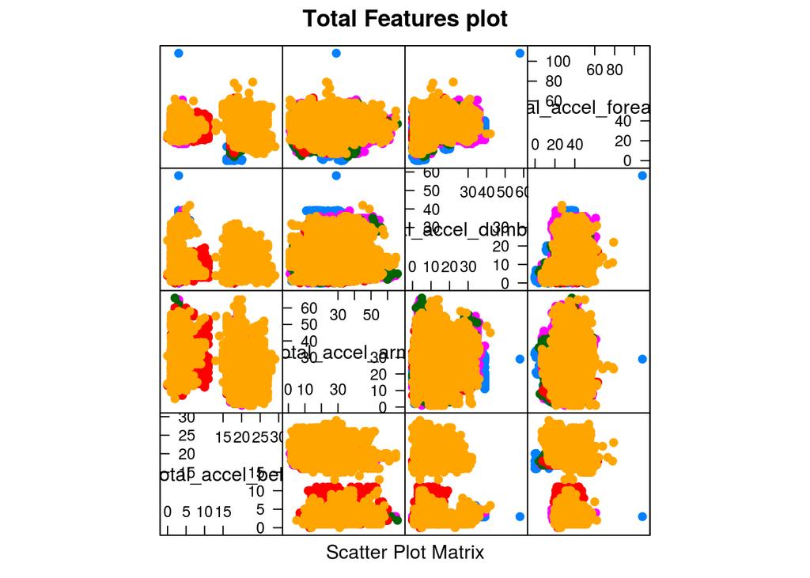

```r
totalCols <- which(grepl("^total", colnames(training), ignore.case = F))
totals <- training[, totalCols]
featurePlot(x = totals, y = training$classe, pch = 19, main = "Total Features plot",
    plot = "pairs")
```

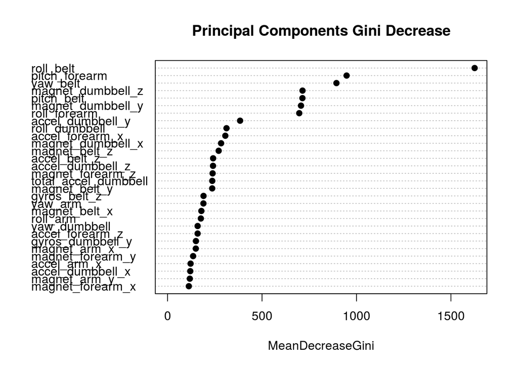

```r
varImpPlot(mod2$finalModel, sort = TRUE, pch = 19, col = 1, cex = 1,
    main = "Principal Components Gini Decrease")
```

### Random Forest plot

Plot with the selected classification model.

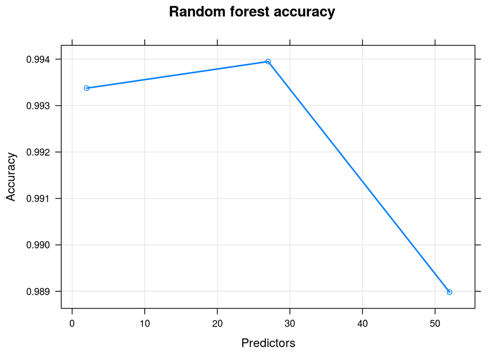

```r
plot(mod2, log = "y", lwd = 2, main = "Random forest accuracy", xlab = "Predictors",
    ylab = "Accuracy")
```

## Prediction on Test Dataset

We will now try to classificate the 20 different test cases from the original test dataset using the described model, obtaining the following results:

```r
testPrediction <- predict(mod2, newdata = testing)
testPrediction
```

```
##  [1] B A B A A E D B A A B C B A E E A B B B
## Levels: A B C D E
```